# Practical Machine Learning: Final Project

# Executive Summary

This analysis provides an overview of the prediction results of the weightlifting dataset. The goal was to predict the 20 observations in the test set.

That was done by: - Preprocessing the data to remove NA’s or irrelevant information (like user identification) - Splitting the training set into a training and validation set and setting model parameters - fitting a random forest model and using it to predict the results

# Model

This data comes from the Weight Lifting Dataset within the [Human Activity Recognition Project](http://groupware.les.inf.puc-rio.br/har)

Training data is [available here](https://d396qusza40orc.cloudfront.net/predmachlearn/pml-training.csv), and the testing data is [provided here](https://d396qusza40orc.cloudfront.net/predmachlearn/pml-testing.csv).

First, we download the data

```r
library(tidyverse)
library(readr)
library(caret)
training <- read_csv("https://d396qusza40orc.cloudfront.net/predmachlearn/pml-training.csv")
testing <- read_csv("https://d396qusza40orc.cloudfront.net/predmachlearn/pml-testing.csv")
dim(training); dim(testing)
```

```
[1] 19622   160
[1]  20 160
```

The goal of the project is to predict the “classe” variable, which is the last column in the dataset.

```r
as.tibble(head(training))
```

| X1 | user_name | raw_timestamp_part_1 | raw_timestamp_part_2 | cvtd_timestamp | new_window | num_window | roll_belt | pitch_belt | yaw_belt | total_accel_belt | kurtosis_roll_belt | kurtosis_picth_belt | kurtosis_yaw_belt | skewness_roll_belt | skewness_roll_belt.1 | skewness_yaw_belt | max_roll_belt | max_picth_belt | max_yaw_belt | min_roll_belt | min_pitch_belt | min_yaw_belt | amplitude_roll_belt | amplitude_pitch_belt | amplitude_yaw_belt | var_total_accel_belt | avg_roll_belt | stddev_roll_belt | var_roll_belt | … |
| --- | --- | --- | --- | --- | --- | --- | --- | --- | --- | --- | --- | --- | --- | --- | --- | --- | --- | --- | --- | --- | --- | --- | --- | --- | --- | --- | --- | --- | --- | --- |
| 1 | carlitos | 1323084231 | 788290 | 05/12/2011 11:23 | no | 11 | 1.41 | 8.07 | -94.4 | 3 | NA | NA | NA | NA | NA | NA | NA | NA | NA | NA | NA | NA | NA | NA | NA | NA | NA | NA | NA | … |
| 2 | carlitos | 1323084231 | 808298 | 05/12/2011 11:23 | no | 11 | 1.41 | 8.07 | -94.4 | 3 | NA | NA | NA | NA | NA | NA | NA | NA | NA | NA | NA | NA | NA | NA | NA | NA | NA | NA | NA | … |
| 3 | carlitos | 1323084231 | 820366 | 05/12/2011 11:23 | no | 11 | 1.42 | 8.07 | -94.4 | 3 | NA | NA | NA | NA | NA | NA | NA | NA | NA | NA | NA | NA | NA | NA | NA | NA | NA | NA | NA | … |
| 4 | carlitos | 1323084232 | 120339 | 05/12/2011 11:23 | no | 12 | 1.48 | 8.05 | -94.4 | 3 | NA | NA | NA | NA | NA | NA | NA | NA | NA | NA | NA | NA | NA | NA | NA | NA | NA | NA | NA | … |
| 5 | carlitos | 1323084232 | 196328 | 05/12/2011 11:23 | no | 12 | 1.48 | 8.07 | -94.4 | 3 | NA | NA | NA | NA | NA | NA | NA | NA | NA | NA | NA | NA | NA | NA | NA | NA | NA | NA | NA | … |
| 6 | carlitos | 1323084232 | 304277 | 05/12/2011 11:23 | no | 12 | 1.45 | 8.06 | -94.4 | 3 | NA | NA | NA | NA | NA | NA | NA | NA | NA | NA | NA | NA | NA | NA | NA | NA | NA | NA | NA | … |

```r
as.tibble(head(testing))
```

| X1 | user_name | raw_timestamp_part_1 | raw_timestamp_part_2 | cvtd_timestamp | new_window | num_window | roll_belt | pitch_belt | yaw_belt | total_accel_belt | kurtosis_roll_belt | kurtosis_picth_belt | kurtosis_yaw_belt | skewness_roll_belt | skewness_roll_belt.1 | skewness_yaw_belt | max_roll_belt | max_picth_belt | max_yaw_belt | min_roll_belt | min_pitch_belt | min_yaw_belt | amplitude_roll_belt | amplitude_pitch_belt | amplitude_yaw_belt | var_total_accel_belt | avg_roll_belt | stddev_roll_belt | var_roll_belt | … |
| --- | --- | --- | --- | --- | --- | --- | --- | --- | --- | --- | --- | --- | --- | --- | --- | --- | --- | --- | --- | --- | --- | --- | --- | --- | --- | --- | --- | --- | --- | --- |
| 1 | pedro | 1323095002 | 868349 | 05/12/2011 14:23 | no | 74 | 123.00 | 27.00 | -4.75 | 20 | NA | NA | NA | NA | NA | NA | NA | NA | NA | NA | NA | NA | NA | NA | NA | NA | NA | NA | NA | … |
| 2 | jeremy | 1322673067 | 778725 | 30/11/2011 17:11 | no | 431 | 1.02 | 4.87 | -88.90 | 4 | NA | NA | NA | NA | NA | NA | NA | NA | NA | NA | NA | NA | NA | NA | NA | NA | NA | NA | NA | … |
| 3 | jeremy | 1322673075 | 342967 | 30/11/2011 17:11 | no | 439 | 0.87 | 1.82 | -88.50 | 5 | NA | NA | NA | NA | NA | NA | NA | NA | NA | NA | NA | NA | NA | NA | NA | NA | NA | NA | NA | … |
| 4 | adelmo | 1322832789 | 560311 | 02/12/2011 13:33 | no | 194 | 125.00 | -41.60 | 162.00 | 17 | NA | NA | NA | NA | NA | NA | NA | NA | NA | NA | NA | NA | NA | NA | NA | NA | NA | NA | NA | … |
| 5 | eurico | 1322489635 | 814776 | 28/11/2011 14:13 | no | 235 | 1.35 | 3.33 | -88.60 | 3 | NA | NA | NA | NA | NA | NA | NA | NA | NA | NA | NA | NA | NA | NA | NA | NA | NA | NA | NA | … |
| 6 | jeremy | 1322673149 | 510661 | 30/11/2011 17:12 | no | 504 | -5.92 | 1.59 | -87.70 | 4 | NA | NA | NA | NA | NA | NA | NA | NA | NA | NA | NA | NA | NA | NA | NA | NA | NA | NA | NA | … |

```r
cols <- colnames(training[,colMeans(is.na(training.train))==0])
cols <- cols[-c(1:5)]
cols
```

```
 [1] "new_window"           "num_window"           "roll_belt"            "pitch_belt"
 [5] "yaw_belt"             "total_accel_belt"     "gyros_belt_x"         "gyros_belt_y"
 [9] "gyros_belt_z"         "accel_belt_x"         "accel_belt_y"         "accel_belt_z"
[13] "magnet_belt_x"        "magnet_belt_y"        "magnet_belt_z"        "roll_arm"
[17] "pitch_arm"            "yaw_arm"              "total_accel_arm"      "gyros_arm_x"
[21] "gyros_arm_y"          "gyros_arm_z"          "accel_arm_x"          "accel_arm_y"
[25] "accel_arm_z"          "magnet_arm_x"         "magnet_arm_y"         "magnet_arm_z"
[29] "roll_dumbbell"        "pitch_dumbbell"       "yaw_dumbbell"         "total_accel_dumbbell"
[33] "gyros_dumbbell_x"     "gyros_dumbbell_y"     "gyros_dumbbell_z"     "accel_dumbbell_x"
[37] "accel_dumbbell_y"     "accel_dumbbell_z"     "magnet_dumbbell_x"    "magnet_dumbbell_y"
[41] "magnet_dumbbell_z"    "roll_forearm"         "pitch_forearm"        "yaw_forearm"
[45] "total_accel_forearm"  "gyros_forearm_x"      "gyros_forearm_y"      "gyros_forearm_z"
[49] "accel_forearm_x"      "accel_forearm_y"      "accel_forearm_z"      "magnet_forearm_x"
[53] "magnet_forearm_y"     "magnet_forearm_z"     "classe"
```

```r
trainCols <- training[,cols]
dim(trainCols)
```

```
[1] 19622    55
```

```r
set.seed(13234)

inTrain <- createDataPartition(y = trainCols$classe, p = 0.8, list = FALSE)

trainColsPre <- trainCols[inTrain,]
trainColsTest <- trainCols[-inTrain,]

dim(trainColsPre); dim(trainColsTest)
```

```
[1] 15699    55
[1] 3923   55
```

Next, we set the classe variable as a factor, rather than a character.

```r
trainColsPre$classe <- as.factor(trainColsPre$classe)
trainColsTest$classe <- as.factor(trainColsTest$classe)
```

We then define our training control parameters, to perform a limited number of cross validation iterations to reduce the computational time required.

```r
fitControl <- trainControl(method = "cv", number = 10)
```

We then fit our random forest model. I chose random forest because it tends to be the most accurate model type. I limited the number of trees to 10 to reduce the processing time for the model

```r
modfit <- train(classe ~ ., method = "rf", data = trainCols, trControl = fitControl, ntree = 10)
```

```r
modfit
```

```
Random Forest

19622 samples
   54 predictor
    5 classes: 'A', 'B', 'C', 'D', 'E'

No pre-processing
Resampling: Cross-Validated (10 fold)
Summary of sample sizes: 17659, 17660, 17660, 17660, 17659, 17660, ...
Resampling results across tuning parameters:

  mtry  Accuracy   Kappa
   2    0.9897052  0.9869771
  28    0.9963814  0.9954227
  54    0.9947508  0.9933602

Accuracy was used to select the optimal model using the
 largest value.
The final value used for the model was mtry = 28.
```

```r
predtest <- predict(modfit, newdata = trainColsTest)
pred.acc <- sum(predtest == trainColsTest$classe)/length(trainColsTest$classe)
pred.acc
```

```
[1] 1
```

Next we predict on the final test set.

First we make sure the columns match

```r
cols[55]
```

```
[1] "classe"
```

```r
predcols <- cols[-55]
dim(testing[,predcols])
```

```
[1] 20 54
```

Next we predict using our model.

```r
predfit <- predict(modfit, newdata = testing[,predcols])
```

```r
length(predfit)
```

```
[1] 20
```

```r
predfit
```

```
 [1] B A B A A E D B A A B C B A E E A B B B
Levels: A B C D E
```

This is our solution.

We can plot the cross validation accuracy to confirm what our calculations showed.

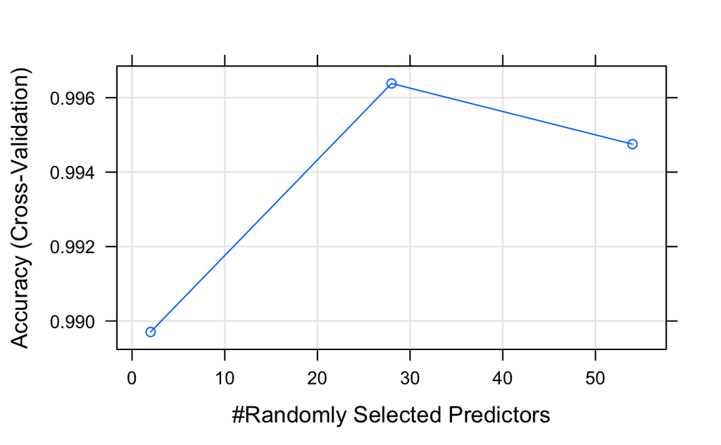

```r
plot(modfit, which = 2)
```

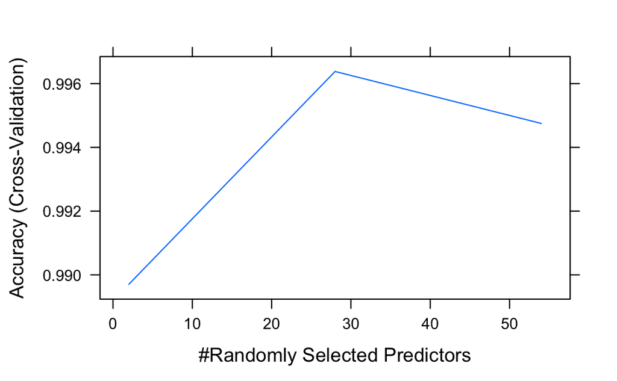

```r
plot(modfit, type = "l")
```